# Riesgo de Homicidio en Medellín

# Andrés Felipe García Orrego - Juan Pablo Robledo Meza

# Introducción

La violencia en Medellín es un problema de larga data, el cual ha tenido momentos críticos que han generado grandes procesos sociales en la ciudad. Sin embargo, esto no se ve reflejado en modelos basados en datos para la construcción de políticas públicas orientadas a un manejo más técnico de los delitos violentos en la ciudad. En particular, los homicidios son crímenes razonablemente bien documentados y de alto impacto para la opinión pública y la ciudad, por lo cual decidimos construir un modelo espacio-temporal bayesiano que estime el riesgo de homicidio usando INLA, con el fin de responder las siguientes preguntas.

# Preguntas

- **¿Cuál es el riesgo de homicidio en un lugar específico en Medellín**.
- **¿Dónde se encuentran los Puntos calientes de violencia?**
- **¿En qué momentos del año o del día hay mayor riesgo de homicidio?**
- **¿Cómo influye la presencia policial en la reducción del riesgo de homicidios?.**
- **¿Cuáles son las métricas más adecuadas para evaluar este tipo de modelos?.**

# Limpieza y Preparación de los Datos de Homicidios en Medellín:

Para garantizar la calidad y pertinencia de los datos en nuestro análisis del riesgo de homicidios en Medellín, realizamos un proceso de limpieza de la base de datos descargada de MeData, que contenía 19,647 registros y 36 columnas.

## Eliminación de Columnas Irrelevantes

Identificamos columnas con valores únicos o sin información relevante para el análisis:

**Columnas con valores constantes**: (CANTIDAD, CONDUCTA, FECHA_INGESTION)

**Columnas con alta cantidad de valores NA**: (GRUPO_ACTOR, ACTIVIDAD_DELICTIVA, DISCAPACIDAD, TESTIGO, entre otras)

Todas estas columnas fueron eliminadas, ya que no aportaban información adicional.

## Selección de Variables Clave.

Con estos datos estructurados, podemos proceder al análisis espacio-temporal del riesgo de homicidios en la ciudad.

## Resultado

# Primer análisis

```r
library(ggplot2)
library(dplyr)
library(lubridate)
library(readr)
library(forcats)
library(sf)
library(ggmap)
library(ggspatial)
library(RColorBrewer)
```

```r
medellin_mapa <- st_read("data/limite_catastral_de_comun/limite_catastral_de_comun.shp")
```

## Homicidios

```r
homicidios <- read.csv("data/homicidios.csv")

# Para analisis temporal
homicidios$FECHA_HECHO <- ymd_hms(homicidios$FECHA_HECHO)
homicidios$AÑO <- year(homicidios$FECHA_HECHO)
homicidios$MES <- month(homicidios$FECHA_HECHO, label = TRUE, abbr = TRUE)

summary(homicidios)
```

```
  FECHA_HECHO                        LONGITUD         LATITUD
 Min.   :2003-01-01 05:00:00.00   Min.   :-75.71   Min.   :6.166
 1st Qu.:2007-11-11 03:15:00.00   1st Qu.:-75.60   1st Qu.:6.243
 Median :2010-09-22 13:00:00.00   Median :-75.57   Median :6.260
 Mean   :2011-05-31 19:14:14.76   Mean   :-75.58   Mean   :6.260
 3rd Qu.:2014-06-30 02:13:45.00   3rd Qu.:-75.56   3rd Qu.:6.284
 Max.   :2023-11-30 00:22:00.00   Max.   :-75.48   Max.   :6.370

     SEXO                EDAD        MODALIDAD            LUGAR
 Length:18488       Min.   : 0.00   Length:18488       Length:18488
 Class :character   1st Qu.:22.00   Class :character   Class :character
 Mode  :character   Median :28.00   Mode  :character   Mode  :character
                    Mean   :30.81
                    3rd Qu.:37.00
                    Max.   :99.00

 NOMBRE_BARRIO         COMUNA               AÑO            MES
 Length:18488       Length:18488       Min.   :2003   May    :1683
 Class :character   Class :character   1st Qu.:2007   Jun    :1645
 Mode  :character   Mode  :character   Median :2010   Jul    :1600
                                       Mean   :2011   Jan    :1582
                                       3rd Qu.:2014   Apr    :1576
                                       Max.   :2023   Aug    :1567
                                                      (Other):8835
```

### Generalidades

#### Modalidad de Homicidio

```r
modalidad <- ggplot(homicidios, aes(y = fct_infreq(MODALIDAD))) +
  geom_bar(fill = "purple") +
  theme_minimal() +
  labs(title = "Frecuencia de homicidios por modalidad", x = "Cantidad", y = "Modalidad")

ggsave("figures/modalidad.png", modalidad, width = 8, height = 6, dpi = 300)
```

#### Homicidios por género

```r
# Calcular el total y los porcentajes
data_pie <- homicidios %>%
  count(SEXO) %>%
  mutate(perc = round(n / sum(n) * 100, 1))  # Redondear a 1 decimal

# Gráfico circular con etiquetas
genero <- ggplot(data_pie, aes(x = "", y = n, fill = SEXO)) +
  geom_bar(stat = "identity", width = 1) +
  coord_polar("y", start = 0) +
  geom_text(aes(label = paste0(perc, "%")),
            position = position_stack(vjust = 0.5), size = 5, color = "white") +  # Etiquetas centradas
  theme_minimal() +
  labs(title = "Distribución de homicidios por género", x = NULL, y = NULL) +
  theme(axis.text = element_blank(), axis.ticks = element_blank(), panel.grid = element_blank())

ggsave("figures/genero.png", genero, width = 8, height = 6, dpi = 300)
```

#### Distribución edad de las víctimas

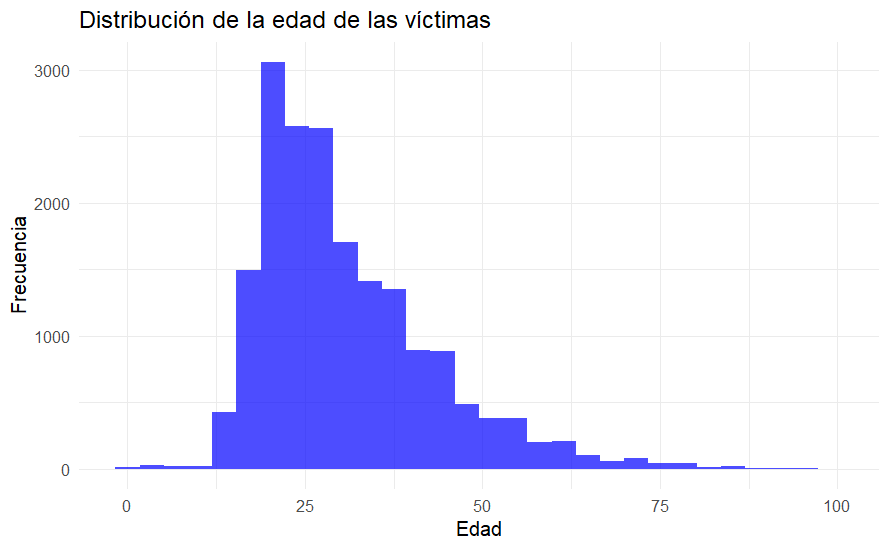

```r
ggplot(homicidios, aes(x = EDAD)) +
  geom_histogram(bins = 30, fill = "blue", alpha = 0.7) +
  theme_minimal() +
  labs(title = "Distribución de la edad de las víctimas", x = "Edad", y = "Frecuencia")
```

### Análisis Temporal

#### Homicidios por año

```r
porAño <- ggplot(homicidios, aes(x = as.factor(AÑO))) +
  geom_bar(fill = "steelblue") +
  theme_minimal() +
  labs(title = "Número de homicidios por año", x = "Año", y = "Cantidad de homicidios")

ggsave("figures/por_año.png", porAño, width = 8, height = 6, dpi = 300)
```

#### Homicidios por mes del año

```r
porMes <- ggplot(homicidios, aes(x = MES)) +
  geom_bar(fill = "darkred") +
  theme_minimal() +
  labs(title = "Número de homicidios por mes", x = "Mes", y = "Cantidad de homicidios")

ggsave("figures/por_mes.png", porMes, width = 8, height = 6, dpi = 300)
```

#### Homicidios por días del año

```r
# Extraer el día y mes de cada homicidio
homicidios <- homicidios %>%
  mutate(DIA = day(as.Date(FECHA_HECHO, format = "%Y-%m-%d")),
         MES = month(as.Date(FECHA_HECHO, format = "%Y-%m-%d"), label = TRUE, abbr = FALSE))

# Contar homicidios por combinación de día y mes
conteo_dia_mes <- homicidios %>%
  count(DIA, MES) %>%
  arrange(desc(n))

# Día y mes con más homicidios
dia_mes_max_homicidios <- conteo_dia_mes %>% slice(1:5)

print(dia_mes_max_homicidios)
```

| DIA | MES | n |
| --- | --- | --- |
| 1 | January | 99 |
| 14 | May | 85 |
| 11 | May | 79 |
| 9 | July | 77 |
| 25 | April | 73 |

```r
NA
```

### Análisis espacial

```r
homicidios_sf <- st_as_sf(homicidios, coords = c("LONGITUD", "LATITUD"), crs = 4326)
```

#### Distribución de Homicidios por modalidad

```r
mapa_mod <- ggplot() +
  geom_sf(data = medellin_mapa, fill = "gray90", color = "black") +  # Mapa base
  geom_sf(data = homicidios_sf, aes(color = MODALIDAD), alpha = 0.6) +  # Homicidios
  scale_color_brewer(palette = "Paired") +  # Paleta de colores con 11 categorías
  theme_minimal() +
  labs(title = "Mapa de homicidios por modalidad", color = "Modalidad") +
  annotation_scale(location = "br") +
  annotation_north_arrow(location = "tl", which_north = "true", style = north_arrow_fancy_orienteering)

ggsave("figures/homicidios_modalidad_mapa.png", mapa_mod, width = 8, height = 6, dpi = 300)
```

## Ultimo año

```r
ultimo_año <- max(homicidios$AÑO, na.rm = TRUE)
homicidios_recientes <- homicidios %>%
  filter(AÑO == ultimo_año)
homicidios_sf <- st_as_sf(homicidios_recientes, coords = c("LONGITUD", "LATITUD"), crs = 4326)

# Transformar a CRS de Medellín (MAGNA-SIRGAS) si es necesario
homicidios_sf <- st_transform(homicidios_sf, st_crs(medellin_mapa))
```

```r
homs_2023 <- ggplot() +
  geom_sf(data = medellin_mapa, fill = "gray90", color = "black") +  # Mapa base
  geom_sf(data = homicidios_sf, aes(color = MODALIDAD), alpha = 0.6, size = 1) +  # Puntos de homicidios del último año
  scale_color_brewer(palette = "Set1") +  # Colores diferenciados
  theme_minimal() +
  labs(title = paste("Mapa de Homicidios en Medellín - Año", ultimo_año),
       color = "Modalidad") +
  annotation_scale(location = "br") +
  annotation_north_arrow(location = "tl", which_north = "true", style = north_arrow_fancy_orienteering)

ggsave("figures/homicidios_2023.png", homs_2023, width = 8, height = 6, dpi = 300)
```

```r
unique(homicidios_recientes$COMUNA)
```

```
 [1] "MANRIQUE"             "ROBLEDO"              "DOCE DE OCTUBRE"
 [4] "VILLA HERMOSA"        "ARANJUEZ"             "SANTA ELENA"
 [7] "SAN JAVIER"           "CASTILLA"             "LA CANDELARIA"
[10] "GUAYABAL"             "BUENOS AIRES"         "SANTA CRUZ"
[13] "BELEN"                "SAN ANTONIO DE PRADO" "POPULAR"
[16] "SAN CRISTOBAL"        "LAURELES"             "LA AMERICA"
[19] "ALTAVISTA"            "EL POBLADO"           "PALMITAS"
```

```r
poblacion <- read.csv("data/poblacion.csv")
poblacion
```

| COMUNA | TOTAL_2018 | TOTAL_2019 | TOTAL_2020 | TOTAL_2021 | TOTAL_2022 | TOTAL_2023 | TOTAL_2024 | TOTAL_2025 | TOTAL_2026 | TOTAL_2027 | TOTAL_2028 | TOTAL_2029 | TOTAL_2030 |
| --- | --- | --- | --- | --- | --- | --- | --- | --- | --- | --- | --- | --- | --- |
| POPULAR | 136986 | 140218 | 143039 | 145235 | 147382 | 149586 | 152365 | 154823 | 157097 | 159185 | 161056 | 162647 | 164029 |
| SANTA CRUZ | 113064 | 115588 | 117744 | 119374 | 120959 | 122573 | 124610 | 126425 | 128072 | 129542 | 130835 | 131961 | 132892 |
| MANRIQUE | 164858 | 168724 | 172090 | 174692 | 177232 | 179793 | 182988 | 185895 | 188577 | 190985 | 193138 | 195105 | 196795 |
| ARANJUEZ | 141312 | 142990 | 144233 | 144815 | 145325 | 145837 | 146611 | 147250 | 147680 | 147905 | 147885 | 147721 | 147337 |
| CASTILLA | 123992 | 125276 | 126200 | 126587 | 126939 | 127289 | 127722 | 128067 | 128261 | 128292 | 128147 | 127765 | 127202 |
| DOCE DE OCTUBRE | 177190 | 179493 | 181235 | 182165 | 183012 | 183889 | 185191 | 186227 | 187015 | 187521 | 187763 | 187738 | 187428 |
| ROBLEDO | 189238 | 194042 | 198274 | 201656 | 204954 | 208305 | 212453 | 216194 | 219669 | 222840 | 225717 | 228344 | 230614 |
| VILLA HERMOSA | 153216 | 157668 | 161728 | 165061 | 168399 | 171776 | 175756 | 179508 | 183078 | 186425 | 189545 | 192463 | 195149 |
| BUENOS AIRES | 155391 | 160045 | 164279 | 167860 | 171416 | 175014 | 179159 | 183086 | 186832 | 190341 | 193632 | 196755 | 199606 |
| LA CANDELARIA | 75913 | 77053 | 77926 | 78478 | 78937 | 79404 | 79892 | 80444 | 80892 | 81199 | 81409 | 81582 | 81671 |

[output cut: 11 more lines]

```r
library(dplyr)

año = 2023

homicidios_recientes <- homicidios %>%
  filter(AÑO == año)
homicidios_sf <- st_as_sf(homicidios_recientes, coords = c("LONGITUD", "LATITUD"), crs = 4326)

homicidios_por_comuna <- homicidios_recientes %>%
  count(COMUNA)

# Unir con la población
homicidios_tasa <- homicidios_por_comuna %>%
  left_join(poblacion, by = "COMUNA") %>%
  mutate(TASA_HOMICIDIOS = ((n / TOTAL_2023) * 100000))

homicidios_tasa
```

| COMUNA | n | TOTAL_2018 | TOTAL_2019 | TOTAL_2020 | TOTAL_2021 | TOTAL_2022 | TOTAL_2023 | TOTAL_2024 | TOTAL_2025 | TOTAL_2026 | TOTAL_2027 | TOTAL_2028 | TOTAL_2029 | TOTAL_2030 | TASA_HOMICIDIOS |
| --- | --- | --- | --- | --- | --- | --- | --- | --- | --- | --- | --- | --- | --- | --- | --- |
| ALTAVISTA | 7 | 38856 | 40150 | 41350 | 42442 | 43556 | 44665 | 45978 | 47189 | 48379 | 49542 | 50641 | 51659 | 52627 | 15.672227 |
| ARANJUEZ | 27 | 141312 | 142990 | 144233 | 144815 | 145325 | 145837 | 146611 | 147250 | 147680 | 147905 | 147885 | 147721 | 147337 | 18.513820 |
| BELEN | 14 | 202931 | 206745 | 210015 | 212479 | 214967 | 217501 | 219847 | 222266 | 224468 | 226416 | 228107 | 229308 | 230195 | 6.436752 |
| BUENOS AIRES | 16 | 155391 | 160045 | 164279 | 167860 | 171416 | 175014 | 179159 | 183086 | 186832 | 190341 | 193632 | 196755 | 199606 | 9.142126 |
| CASTILLA | 19 | 123992 | 125276 | 126200 | 126587 | 126939 | 127289 | 127722 | 128067 | 128261 | 128292 | 128147 | 127765 | 127202 | 14.926663 |
| DOCE DE OCTUBRE | 18 | 177190 | 179493 | 181235 | 182165 | 183012 | 183889 | 185191 | 186227 | 187015 | 187521 | 187763 | 187738 | 187428 | 9.788514 |
| EL POBLADO | 7 | 106805 | 108345 | 109600 | 110479 | 111343 | 112257 | 112850 | 113594 | 114223 | 114730 | 115127 | 115272 | 115267 | 6.235691 |
| GUAYABAL | 8 | 64651 | 65011 | 65146 | 65024 | 64856 | 64713 | 64509 | 64320 | 64052 | 63691 | 63261 | 62714 | 62086 | 12.362277 |
| LA AMERICA | 4 | 85416 | 86403 | 87128 | 87489 | 87849 | 88207 | 88382 | 88714 | 88925 | 89020 | 89028 | 88931 | 88710 | 4.534787 |
| LA CANDELARIA | 68 | 75913 | 77053 | 77926 | 78478 | 78937 | 79404 | 79892 | 80444 | 80892 | 81199 | 81409 | 81582 | 81671 | 85.638003 |

[output cut: 11 more lines]

```r
medellin_mapa <- st_read("data/limite_catastral_de_comun/limite_catastral_de_comun.shp")
medellin_mapa <- medellin_mapa %>%
  rename(COMUNA = nombre)

# Unir con el shapefile de las comunas
medellin_mapa <- medellin_mapa %>%
  left_join(homicidios_tasa, by = "COMUNA")
```

```r
# Graficar el mapa
library(ggplot2)

tasa_2023 <- ggplot(medellin_mapa) +
  geom_sf(aes(fill = TASA_HOMICIDIOS), color = "white") +
  scale_fill_gradient(low = "green", high = "red", na.value = "green") +
  theme_minimal() +
  labs(title = "Tasa de homicidios por cada 100.000 habitantes en Medellín (2023)",
       fill = "Homicidios por 100.000 hab.")

ggsave("figures/tasa_2023.png", tasa_2023, width = 8, height = 6, dpi = 300)
```

## Cuadrantes de Policía

```r
# FALTA QUE DANIEL NOS PASE LOS DATOS
```

[output not shown]

## Analisís bivariado de los datos:

```r
library(ggplot2)

edad <- ggplot(homicidios, aes(x = EDAD, fill = SEXO)) +
  geom_histogram(binwidth = 5, alpha = 0.6, position = "identity", color = "black") +
  scale_x_continuous(breaks = seq(min(homicidios$EDAD, na.rm=TRUE),
                                  max(homicidios$EDAD, na.rm=TRUE),
                                  by = 5)) +
  labs(title = "Distribución de Edades de las Víctimas por Género",
       x = "Edad",
       y = "Frecuencia",
       fill = "Género") +
  theme_minimal()

ggsave("figures/edad.png", edad, width = 8, height = 6, dpi = 300)
```

##Homicidios por sectores.

```r
head(homicidios_sf)
```

```
Simple feature collection with 6 features and 10 fields
Geometry type: POINT
Dimension:     XY
Bounding box:  xmin: 4711853 ymin: 2249352 xmax: 4718559 ymax: 2255655
Projected CRS: MAGNA-SIRGAS_Origen-Nacional
          FECHA_HECHO   SEXO EDAD     MODALIDAD              LUGAR
1 2023-01-01 12:30:00 Hombre   23 Cortopunzante        Vía pública
2 2023-01-01 08:22:00 Hombre   19 Cortopunzante Casa o apartamento
3 2023-01-01 14:00:00 Hombre   33 Arma de fuego        Vía pública
4 2023-01-01 07:00:00 Hombre   20 Arma de fuego        Vía pública
5 2023-01-01 12:20:00 Hombre   28 Cortopunzante        Vía pública
6 2023-01-02 08:00:00  Mujer   22 Cortopunzante        Vía pública
         NOMBRE_BARRIO          COMUNA  AÑO     MES DIA
1          Las Granjas        MANRIQUE 2023 January   1
2         Fuente Clara         ROBLEDO 2023 January   1
3 Universidad Nacional         ROBLEDO 2023 January   1
4        Progreso No.2 DOCE DE OCTUBRE 2023 January   1
5               Enciso   VILLA HERMOSA 2023 January   1
6              Moravia        ARANJUEZ 2023 January   2
                 geometry
1 POINT (4718559 2252736)
2 POINT (4711853 2252296)
3 POINT (4715254 2250509)
4 POINT (4714226 2255655)
5 POINT (4717777 2249352)
6 POINT (4716292 2252042)
```

# Modelo Estadístico

Nos basaremos en el documento https://www.dspace.espol.edu.ec/bitstream/123456789/56598/1/T-110414%20CLAUDIA%20RODR%C3%8DGUEZ%20MENDEZ%20Y%20SAMANTHA%20ORTIZ%20SANTAMARIA%20INGENIERA%20ESTADISTICA.pdf?.com. En el cual se propone un modelo similar para la cuidadd de Guayaquil en ecuador, debido a que encontramos caracteristicas importantes en comun, entre ellas el numero de habitantes y el tamaño del area metropolitana. Ademas de condiciones cultares, sociales y delictivas similares El modelo seguirá un enfoque **jerárquico bayesiano**, con una **distribución Poisson** para los homicidios y un predictor que incluye efectos espaciales, temporales y covariables por ultimo la estimación se hara siguiendo el metodo INLA (El cual resulta más rápido para modelos espacio temporales).

$$Y_{i,t}=
Poisson(\lambda_{i,t})$$
.

Donde: - $Y_{i,t}$ es el número de homicidios en la comuna i en el tiempo t

- $\lambda_{i,t}$ es la **Tasa esperada de homicidios** en la comuna i en el tiempo t

Nuestro modelo lineal predictor se define como:

$log(\lambda_{i,t})=\beta_0+\beta_{policia}x_{policia,i,t}+f(espacio)+f(tiempo)+f(espacio-tiempo)$

Donde:

$\beta_0$: Intercepto general

$x_{policia,i,t}$: Cantidad de estaciones de policia en la comuna i en el tiempo t

$\beta_{policia}$: Efecto de la presencia policial sobre los homicidios

$f(espacio)$: Efecto espacial que modela **dependencias geográficas**

$f(tiempo$: Efecto temporal que captura **tendencias en el tiempo** (Puede ser una serie de tiempo)

$f(espacio-tiempo)$: Interacción espacio temporal para modelar **cómo varían los homicidios de cada comuna a lo largo del tiempo**

# Siguientes pasos:

- Obtener datos poblacionales de las comunas.
- Obtener información acerca de los cuadrante.
- Análisis bivariado de los datos.
- Implementar INLA
- Analizar resultados y storing telling